# Project: Analysis Summary of Surgical Regression Model

10/24/2022

## The Context and the Data Dictionary

A hospital surgical unit was interested in predicting survival in patients undergoing a particular type of liver operation. A random selection of 54 patients was available for analysis. For each patient record, the following information was extracted from the pre-operation evaluation (We assume that higher values of X1 through X4 are desirable). The survival times were made available based off another data collection phase of the project:

Y: Survival Time (in days)

X1: Blood Clotting Score

X2: Prognostic Index

X3: Enzyme Function Test Score

X4: Liver Function Test Score

X5: Age, in years

X6: Indicator variable for gender (0 = female, 1 = male)

## Read and Prep the Data

```r
# Read the data from the working directory
Survival <- read_csv("Surgical.csv")
# Relabel the variables; transform the response variable;
# convert gender to nominal
Mod_Survival <- Survival %>%
    rename(Blood_Clotting_Score = "x1", Prognostic_Index = "x2",
        Enzyme_Score = "x3", Liver_Score = "x4", Age = "x5",
        Gender = "x6", Survival_Days = "y") %>%
    mutate(ln_Survival_Days = log(Survival_Days)) %>%
    mutate(Gender = as.factor(Gender))
```

## Distribution Analysis for Survival_Days and log(Survival_Days)

The distribution of survival days (Survival_Days variable) of patients is right skewed. For a multiple linear regression model, we need reasonably normality of the variable. The distribution of the natural log of survival days is reasonably normal. Therefore, we model using the “transformed variable” since this transformation takes care of the skewness and more than likely takes care of the equal variance assumption.

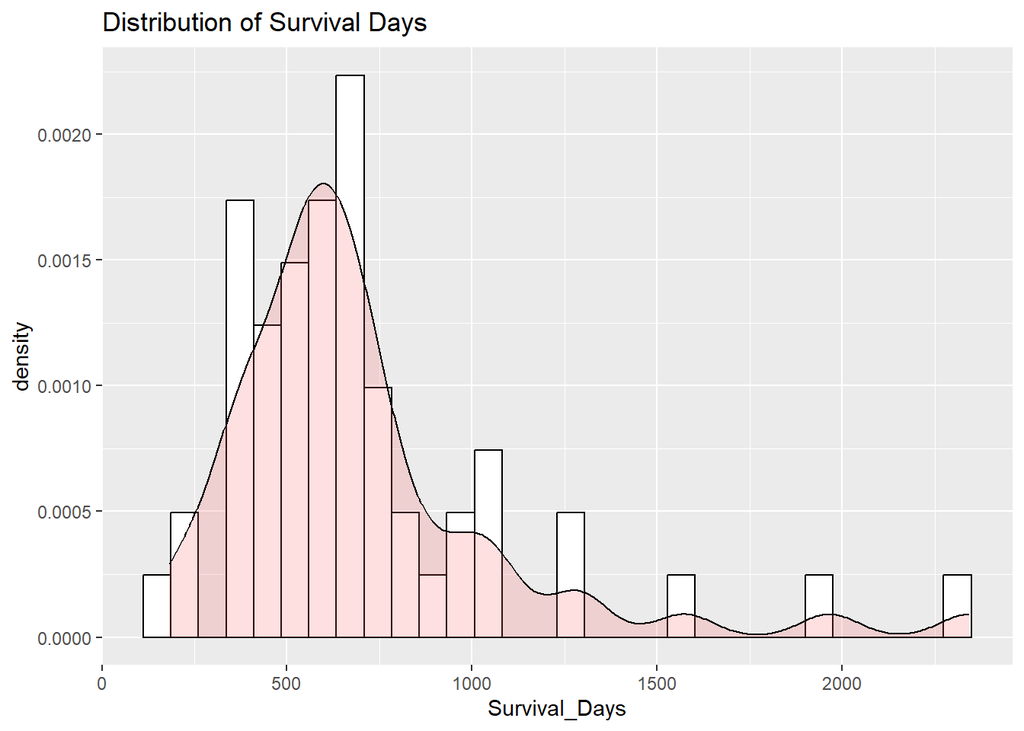

```r
# Distribution plot of Survival Days
ggplot(Mod_Survival, aes(x = Survival_Days)) + geom_histogram(aes(y = ..density..),
    colour = "black", fill = "white") + geom_density(alpha = 0.2,
    fill = "#FF6666") + ggtitle("Distribution of Survival Days")
```

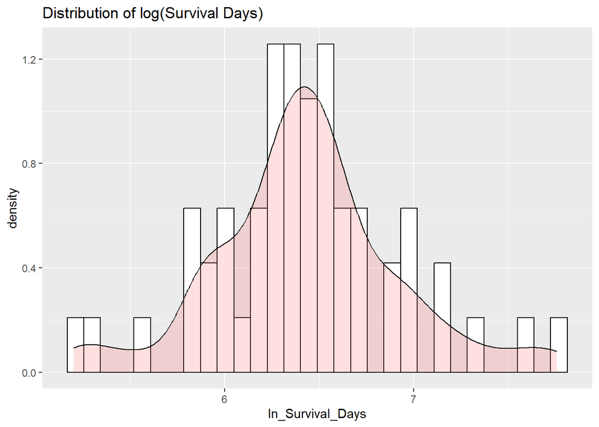

```r
# Distribution plot of log(Survival Days)
ggplot(Mod_Survival, aes(x = ln_Survival_Days)) + geom_histogram(aes(y = ..density..),
    colour = "black", fill = "white") + geom_density(alpha = 0.2,
    fill = "#FF6666") + ggtitle("Distribution of log(Survival Days)")
```

## Get the Correlation Matrix

```r
attach(Mod_Survival)
res <- cor(cbind(Blood_Clotting_Score, Prognostic_Index, Enzyme_Score,
    Liver_Score, Age, Gender, ln_Survival_Days))
round(res, 2)
```

```
##                      Blood_Clotting_Score Prognostic_Index Enzyme_Score Liver_Score   Age Gender ln_Survival_Days
## Blood_Clotting_Score                 1.00             0.09        -0.15        0.50 -0.02   0.04             0.25
## Prognostic_Index                     0.09             1.00        -0.02        0.37 -0.05   0.12             0.47
## Enzyme_Score                        -0.15            -0.02         1.00        0.42 -0.01   0.14             0.65
## Liver_Score                          0.50             0.37         0.42        1.00 -0.21   0.30             0.65
## Age                                 -0.02            -0.05        -0.01       -0.21  1.00   0.01            -0.15
## Gender                               0.04             0.12         0.14        0.30  0.01   1.00             0.23
## ln_Survival_Days                     0.25             0.47         0.65        0.65 -0.15   0.23             1.00
```

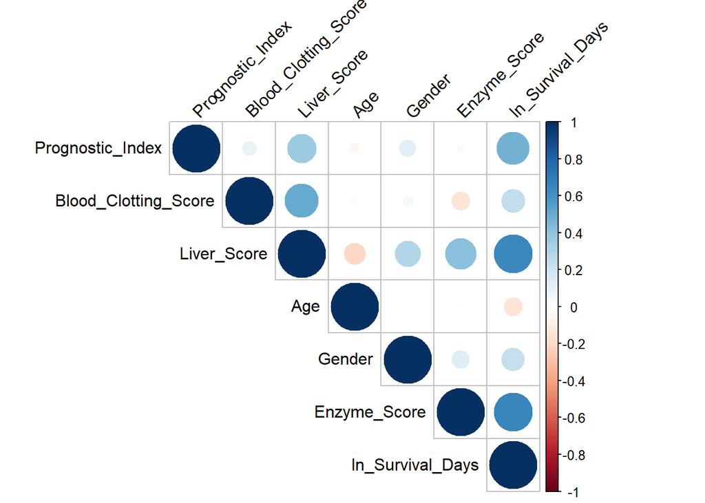

```r
corrplot(res, type = "upper", order = "hclust", tl.col = "black",
    tl.srt = 45)
```

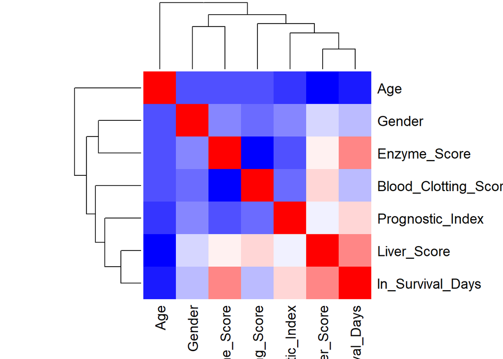

```r
col <- colorRampPalette(c("blue", "white", "red"))(20)
heatmap(x = res, col = col, symm = TRUE)
```

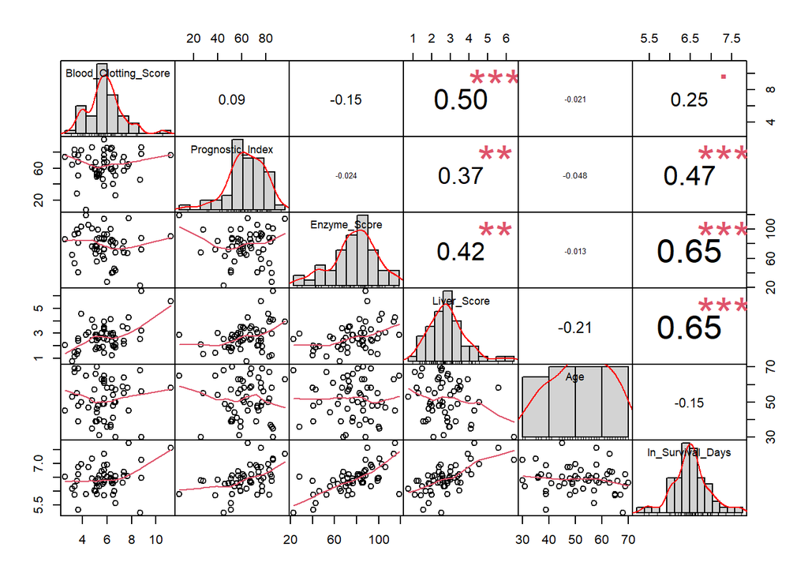

```r
my_data <- Mod_Survival[, c(1, 2, 3, 4, 5, 8)]
chart.Correlation(my_data, histogram = TRUE, pch = 19)
```

## Comparing Survival Times between Males and Females

We notice that males have higher survival times than females. The median survival time for males is higher than the median survival time for females.

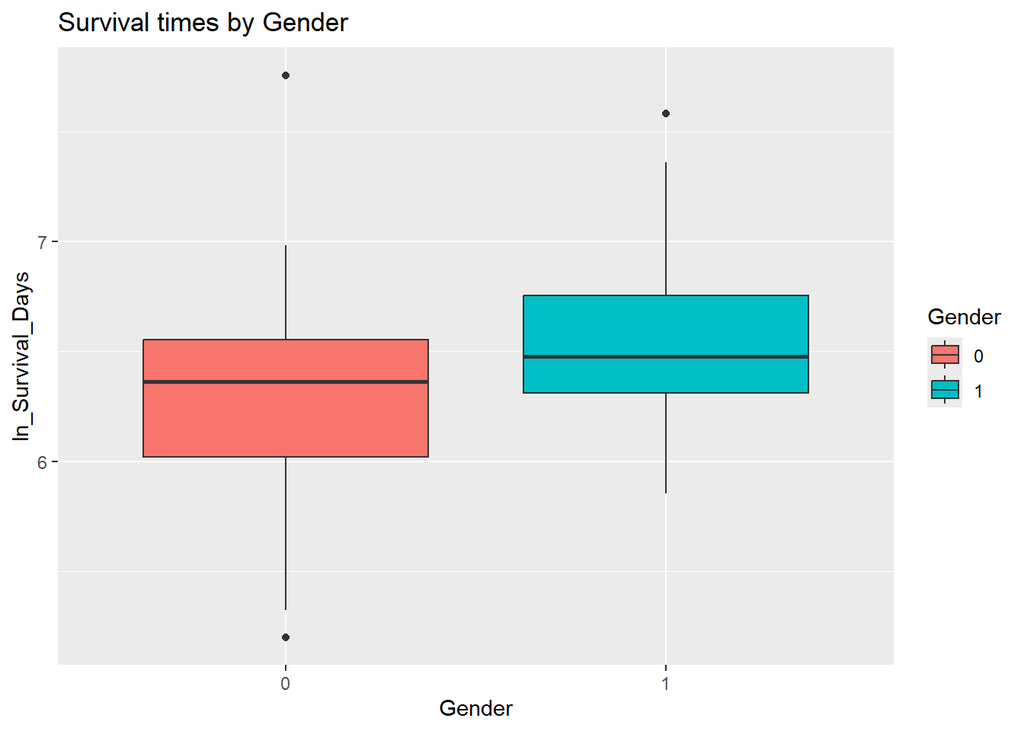

```r
ggplot(Mod_Survival, aes(x = Gender, y = ln_Survival_Days, fill = Gender)) +
    geom_boxplot() + ggtitle("Survival times by Gender")
```

## The Model Build

Ln(y) = 4.035 + 0.095Blood Clotting Score +0.013 Prognostic Index + 0.016Enzyme_Score -0.0031 Liver_Score -0.0048Age + 0.066Gender  
Interpretation of the impact each variable has on survival time: Holding all other variables constant, a one unit increase in Blood Clotting Score is associated with a 9.5% increase in survival time. Holding all other variables constant, a one unit increase in Prognostic Index Score is associated with a 1.3% increase in survival time. Holding all other variables constant, a one unit increase in Enzyme Score is associated with a 1.6% increase in survival time. Holding all other variables constant, a one unit increase in Liver Score is associated with a 0.3% decrease in survival time. Holding all other variables constant, a one unit increase in Age is associated with a 0.5% decrease in survival time. Holding all other variables constant, males on average have a 6.6% higher survival time than females.

```r
Survival_OLS <- lm(ln_Survival_Days ~ ., data = Mod_Survival[,
    -7])
summary(Survival_OLS)
```

```
##
## Call:
## lm(formula = ln_Survival_Days ~ ., data = Mod_Survival[, -7])
##
## Residuals:
##      Min       1Q   Median       3Q      Max
## -0.42847 -0.16913  0.00696  0.18167  0.50226
##
## Coefficients:
##                       Estimate Std. Error t value Pr(>|t|)
## (Intercept)           4.034857   0.297463  13.564  < 2e-16 ***
## Blood_Clotting_Score  0.094858   0.029328   3.234  0.00223 **
## Prognostic_Index      0.013020   0.002304   5.650 9.08e-07 ***
## Enzyme_Score          0.016245   0.002114   7.683 7.59e-10 ***
## Liver_Score          -0.003132   0.055256  -0.057  0.95503
## Age                  -0.004863   0.003215  -1.513  0.13709
## Gender1               0.066140   0.072024   0.918  0.36315
## ---
## Signif. codes:  0 '***' 0.001 '**' 0.01 '*' 0.05 '.' 0.1 ' ' 1
##
## Residual standard error: 0.2486 on 47 degrees of freedom
## Multiple R-squared:  0.7731, Adjusted R-squared:  0.7441
## F-statistic: 26.69 on 6 and 47 DF,  p-value: 1.391e-13
```

## Boxplot of the Residuals

The boxplot of residuals incidates that the normality of the residuals assumption is not violated.

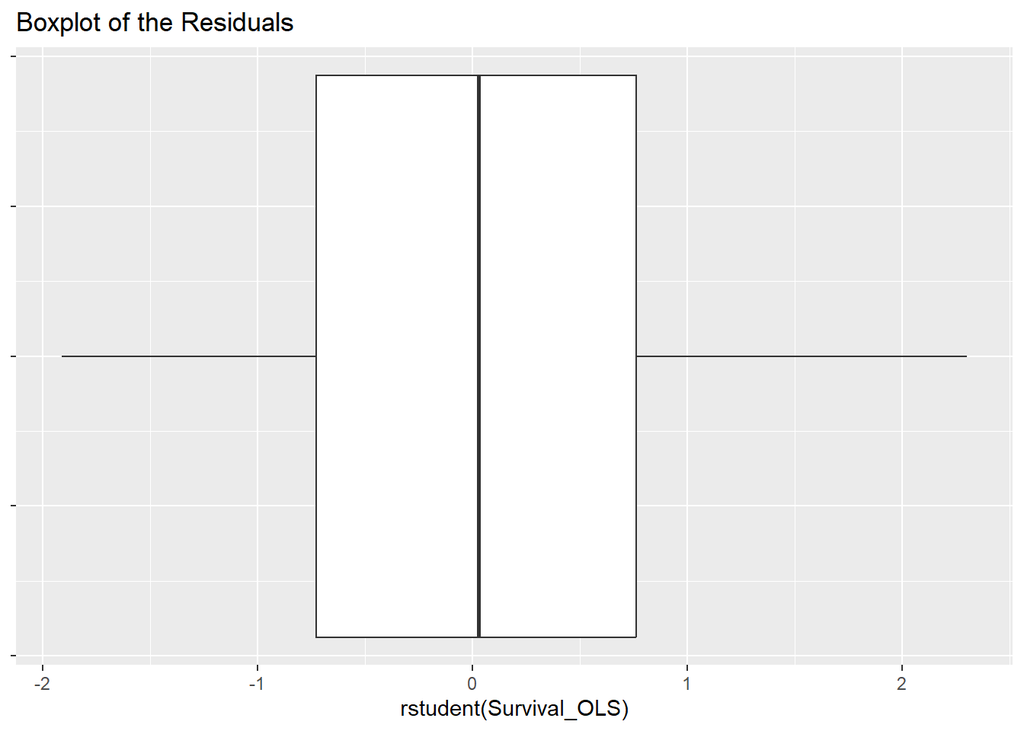

```r
ggplot(Survival_OLS, aes(x = 1, y = rstudent(Survival_OLS))) +
    geom_boxplot() + xlab(NULL) + ggtitle("Boxplot of the Residuals") +
    theme(axis.text.y = element_blank()) + coord_flip()
```

## Residual Analysis

4 assumptions are being tested here: Linearity, normality of the residuals, the homogeneous variance assumption, and whether the model has been correctly specified. The residual plots indicate that these assumptions hold.

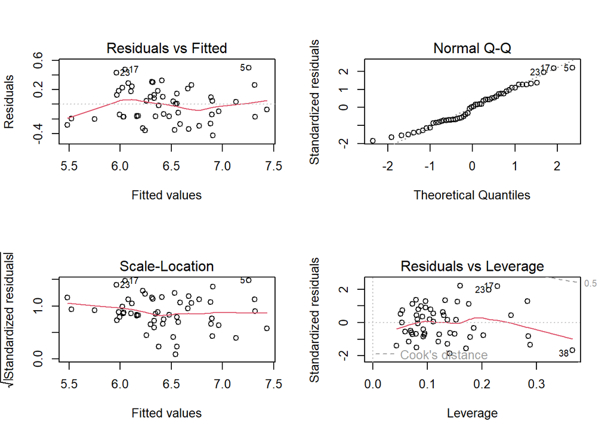

```r
# Normal Probability Plots and Check for Homoscedasticity
par(mfrow = c(2, 2))  # Change the panel layout to 2 x 2
plot(Survival_OLS)
```

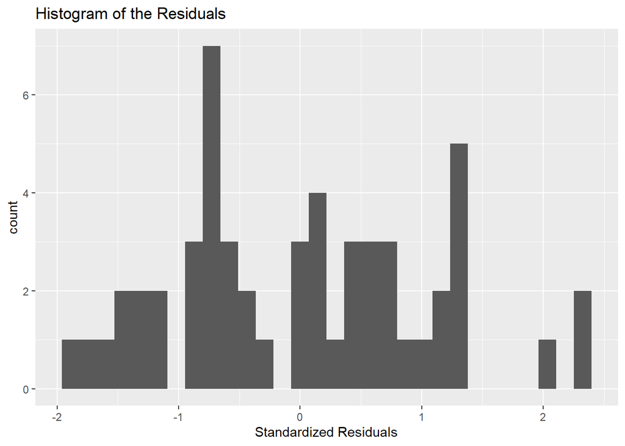

```r
par(mfrow = c(1, 1))  # Change back to 1 x 1

# Histogram of the Residuals
ggplot(Survival_OLS, aes(x = rstudent(Survival_OLS))) + geom_histogram() +
    ggtitle("Histogram of the Residuals") + xlab("Standardized Residuals")
```

## Residuals versus Predictor Plots

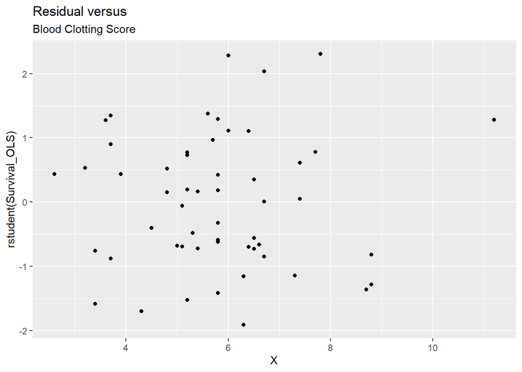

```r
getPlots <- function(X, title) {
    return(ggplot(Mod_Survival, aes(x = X, y = rstudent(Survival_OLS))) +
        geom_point() + ggtitle("Residual versus ", title)) +
        xlab(title)
}
getPlots(Mod_Survival$Blood_Clotting_Score, "Blood Clotting Score")
```

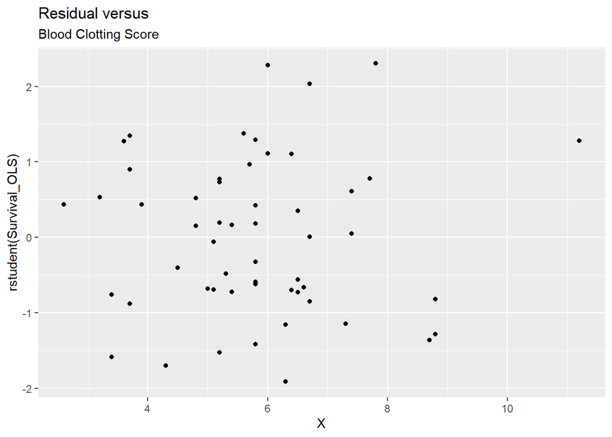

```r
getPlots(Mod_Survival$Blood_Clotting_Score, "Blood Clotting Score")
```

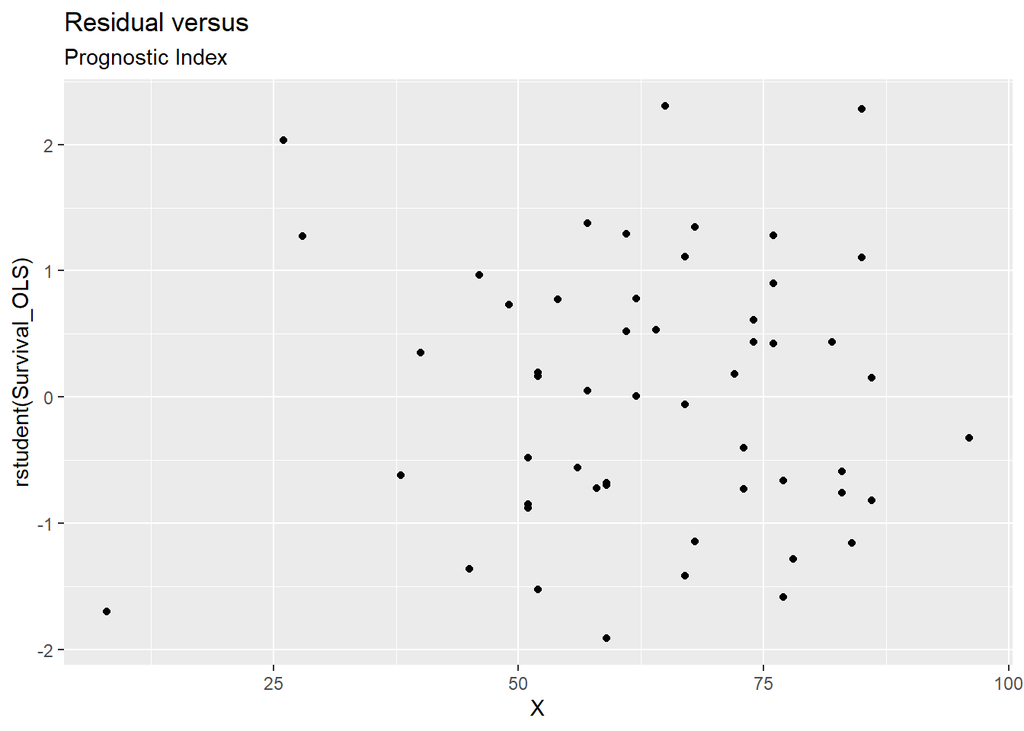

```r
getPlots(Mod_Survival$Prognostic_Index, "Prognostic Index")
```

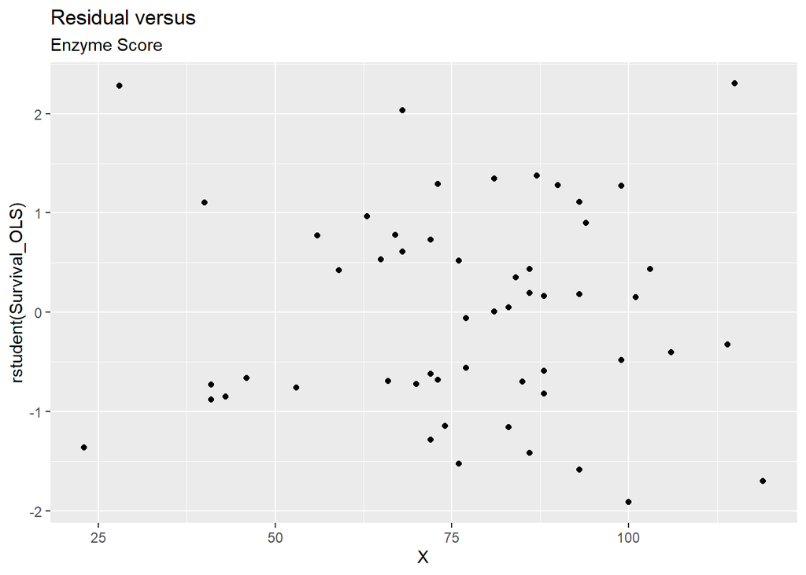

```r
getPlots(Mod_Survival$Enzyme_Score, "Enzyme Score")
```

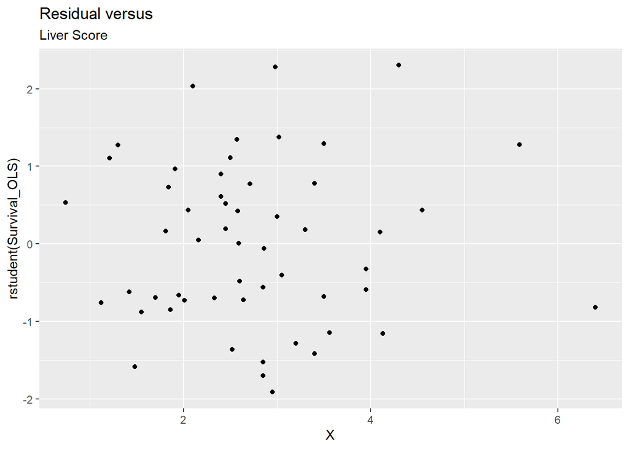

```r
getPlots(Mod_Survival$Liver_Score, "Liver Score")
```

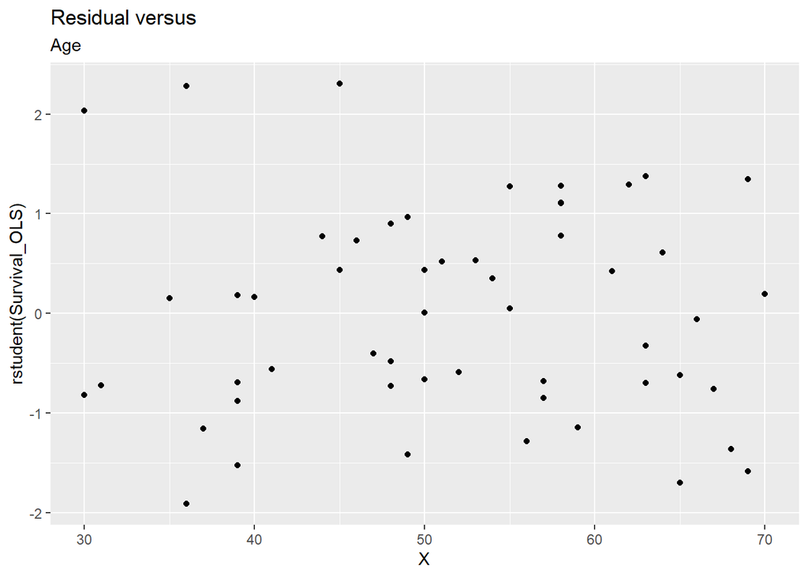

```r
getPlots(Mod_Survival$Age, "Age")
```

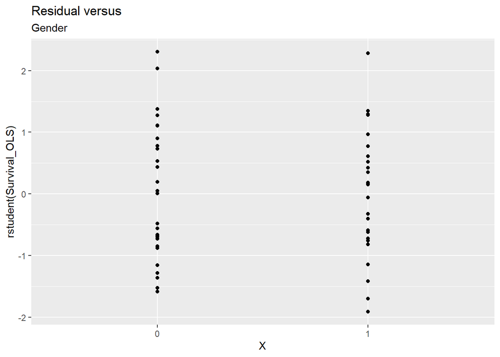

```r
getPlots(Mod_Survival$Gender, "Gender")
```

## Get the Variance Inflation Factors

```r
vif(Survival_OLS)
```

```
## Blood_Clotting_Score     Prognostic_Index         Enzyme_Score          Liver_Score                  Age               Gender
##             1.895197             1.300836             1.731569             2.999279             1.096694             1.126731
```

## The Global F Test

Testing overall model significance. H0: The model is not significant.  H0: Beta1 = … = Beta6 = 0 H1: The model is significant.  H1: At least one of the regression coefficients <> 0 State the Type 1 Error Rate: 5% F Statistic Value? 26.69 with a p – value ~ 0 Conclusion: Reject the null hypothesis. Model relating natural log of survival times to the 4 lab variables, age, and gender is significant.

## The t-Tests

Blood Clotting Score H0: Beta1 = 0 vs H1: Beta1 <>0 Type 1 error rate is 5% T test statistic value is 3.234 with a p-value of 0.00223 Reject H0: Blood Clotting Score is related with Survival Time. Prognostic Index H0: Beta1 = 0 vs H1: Beta1 <>0 Type 1 error rate is 5% T test statistic value is 5.650 with a p-value of 0.000000908 Reject H0: Prognostic Index is related with Survival Time.

## The Confidence Intervals for the individual parameters

We are 95% confident that the true/unknown regression coefficient for Blood Clotting Score is between 0.036 and 0.154. We are 95% confident that the true/unknown regression coefficient for Prognostic Index Score is between 0.008 and 0.0177. We are 95% confident that the true/unknown regression coefficient for Enzyme Score is between 0.012 and 0.020. We are 95% confident that the true/unknown regression coefficient for Liver Score is between -0.114 and 0.108. We are 95% confident that the true/unknown regression coefficient for Age is between (negative) -0.011 and 0.002. We are 95% confident that the true/unknown regression coefficient for Gender is between -.079 and 0.211.

```r
# The default is 95%; Using level option to change this
confint(Survival_OLS)
```

```
##                             2.5 %      97.5 %
## (Intercept)           3.436438885 4.633275320
## Blood_Clotting_Score  0.035857544 0.153859316
## Prognostic_Index      0.008383624 0.017655412
## Enzyme_Score          0.011991834 0.020499056
## Liver_Score          -0.114293741 0.108029089
## Age                  -0.011331960 0.001605163
## Gender1              -0.078753935 0.211033723
```

## Calculating the Predicted Value

```r
predict(Survival_OLS, data.frame(Blood_Clotting_Score = 3, Prognostic_Index = 40,
    Enzyme_Score = 50, Liver_Score = 2.6, Age = 30, Gender = "1"))
```

```
##        1
## 5.564579
```

## Calculating the Confidence Interval for the Mean Response and Prediction

We are 95% confident that the true mean survival days for all males who are 30 years old and have the medical profile listed in the statement is between 192 and 354 days.

We are 95% confident that the true survival number of days for a male who is 30 years old and has the medical profile listed in the statement is between 145 and 469 days.

```r
newdata = data.frame(Blood_Clotting_Score = 3, Prognostic_Index = 40,
    Enzyme_Score = 50, Liver_Score = 2.6, Age = 30, Gender = "1")
predict(Survival_OLS, newdata, interval = "predict")
```

```
##        fit      lwr      upr
## 1 5.564579 4.978575 6.150584
```

```r
predict(Survival_OLS, newdata, interval = "confidence")
```

```
##        fit      lwr      upr
## 1 5.564579 5.259231 5.869927
```